# DRAFT: Estuary Tipping Point Analysis

### Part I: Caloosahatchee River Estuary

Paul Julian, PhD | April 16, 2020

## Motivation

- Initial discussions regarding possible management actions relative to LOSOM development to reduce or mitigate algal blooms.

## Objective

- Evalute potential tipping points within the freshwater portion of the Caloosahatchee River Estuary relative to freshwater inputs (_via S-79_).

- Understanding tipping points may aid in anticipating or expecting potential regime shifts within the estuaries in response to changes in water management and restoration.

.tiny[LOSOM = Lake Okeechobee System Operating Manual [(USACE Webpage)](https://www.saj.usace.army.mil/LOSOM/)]

## Tipping Points

- Vaguely defined in the current literature

- Generally defined as transistion in biological characteristics (i.e. species diversity) relative to a ecological driver (i.e. eutrophication)
  - see Robin et al., (2014) and Vanacker et al., (2015)

- Also discussed relative to long-term state changes in an ecosystem (Glibert et al., 2014).

- Robin et al., 2014. Biodiversity in eutrophicated shallow lakes: determination of tipping points and tools for monitoring. Hydrobiologia 723, 63–75.
- Vanacker et al., 2015. Determining tipping points in aquatic ecosystems: The case of biodiversity and chlorophyll α relations in fish pond systems. Ecological Indicators 52, 184–193.
- Glibert et al., 2014. Eutrophication of a Maryland/Virginia Coastal Lagoon: a Tipping Point, Ecosystem Changes, and Potential Causes. Estuaries and Coasts 37, 128–146.

## Conceptual Framework

- Hypothetically a tipping point analysis is identifying potential breakpoints comparing some biotic metric versus potential driver(s).
  - In the case of Vanacker et al., (2015) the biotic metric were a series of phytoplankton biodiversity indices  _(i.e. Richness, Jackknife Index, Fisher's &alpha;, Simpson Index and Evenness)_ versus a metric of eutrophication _(i.e. spring Chlorophyll-a concentration)_.

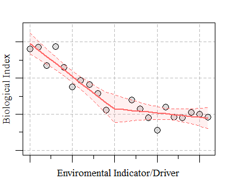

For this analysis
- Environment Indicators/Drivers:
  - S-79 Discharge
  - S-79 TP FWM
  - S-79 TN FWM

- Biological Index:
  - Bloom potential

TP = Total Phosphous; TN = Total Nitrogen; FWM = Flow-weighted Mean

## Bloom Potential

In Lake Okeechobee, several studies (Havens, 1994; Walker and Havens, 1995) have indicated that a Chlorophyll-_a_ (Chl-_a_) concentration of > 40 &mu;g L<sup>-1</sup> was indicative of algal blooms.

In Florida Bay, bloom conditions range from Chl-_A_ concentration of 5 to 20 &mu;g L<sup>-1</sup> (Boyer et al., 2009; Glibert et al., 2009).

In Maryland/Virginia Coastal Bays area, most of the algal blooms were observed with Chl-_A_ concentrations >5 &mu;g L<sup>-1</sup> (Gilbert et al., 2014).

- Boyer, et al., 2009. Phytoplankton bloom status: Chlorophyll a biomass as an indicator of water quality condition in the southern estuaries of Florida, USA. Ecological Indicators 9, S56–S67.
- Glibert, et al., 2009. Florida Bay: Water quality status and trends, historic and emerging algal bloom problems. Contributions in Marine Science 38, 5–17.
- Glibert, P.M., Hinkle, D.C., Sturgis, B., Jesien, R.V., 2014. Eutrophication of a Maryland/Virginia Coastal Lagoon: a Tipping Point, Ecosystem Changes, and Potential Causes. Estuaries and Coasts 37, 128–146.
- Havens, 1994. Relationships of Annual Chlorophyll a Means, Maxima, and Algal Bloom Frequencies in a Shallow Eutrophic Lake (Lake Okeechobee, Florida, USA). Lake and Reservoir Management 10, 133–136.
- Walker and Havens, 1995. Relating Algal Bloom Frequencies to Phosphorus Concentrations in Lake Okeechobee. Lake and Reservoir Management 11, 77–83.

### Data

- Water quality and hydrologic data were retrieved from the South Florida Water Management District (SFWMD) online database ([DBHYDRO]( www.sfwmd.gov/dbhydro)).

- S-77, S-79 and Caloosahatchee River Esturay (CRE) monitoring network.

- Period of Record: May 1, 2004 - April 30, 2019 (WY2005 - 2019).

- Data were screened for fatal qualifers and reversals (i.e. SRP > TP).

- Data reported as less than method detection limit (MDL) were assigned one-half the MDL.

### Statistical Analysis

- Annual Flow-weighted Mean concentrations computed for S-79 and S-77.
  - Water quality was weighted by flow on day of sampling using the `wtd.mean()` function in the `Hmisc` R-library.

- Potential Bloom was estimated for each monitoring location as a proportion of samples with Chl-_a_ was greater than 10  &mu;g L<sup>-1</sup> within a given year.

- _Initially_ segment linear models (`segmented()` in the `segmented` R-library) was used to evaluate change points between S-79 annual total discharge volume, TP and TN FWM relative to the potential bloom frequency.

- Analyses performed in R (Ver 3.6.1)

## Study Area

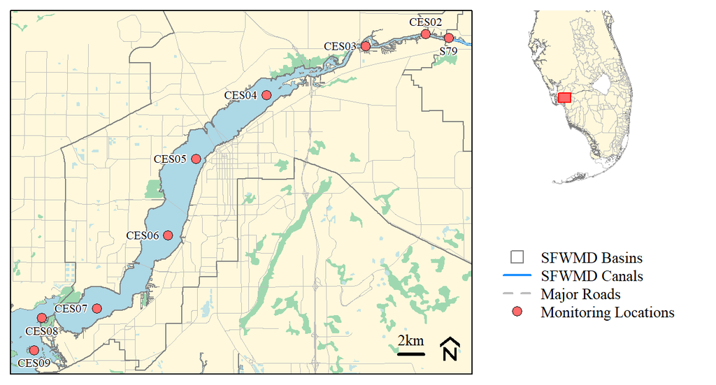

## Freshwater Inputs

Annual discharge and FWM concentrations (&#177; flow-weighted standard deviation) for S-77 and S-79 when data was available.

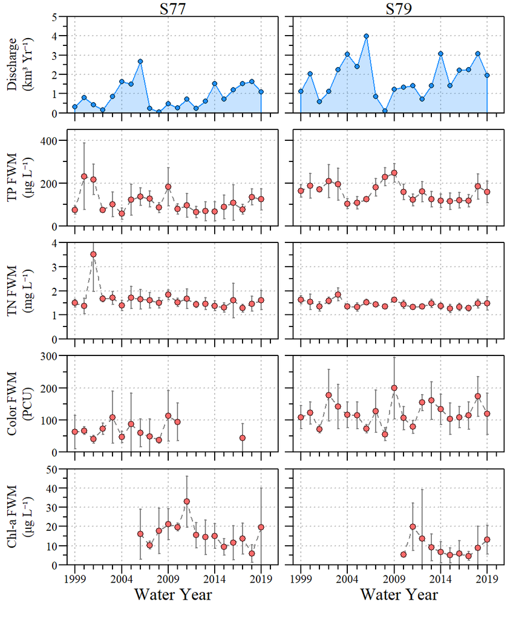

## Estuarine Water Quality

Boxplot (with sample size, numbers above boxplots) of water quality grab samples during the period of record.

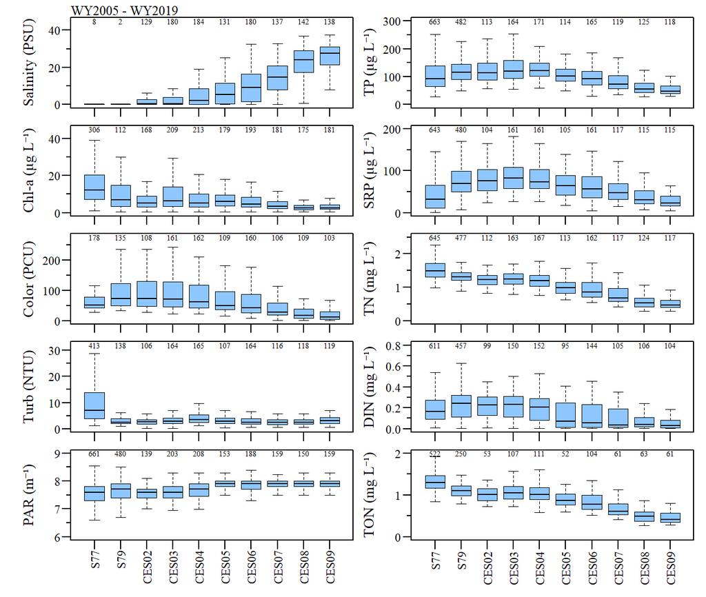

Annual empirical cumulative distribution function (eCDF) &#177; 95% Confidence Interval for CES02, 03, 04, and 05. Potential bloom metric (Chl-_a_ 10 &mu;g L<sup>-1</sup>) identified with dashed black line).

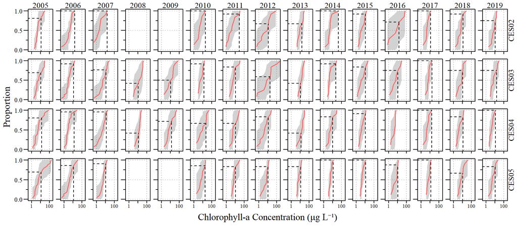

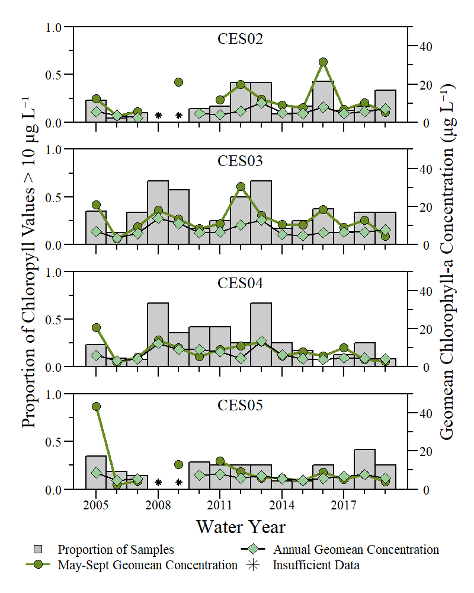

### Segmented Regression

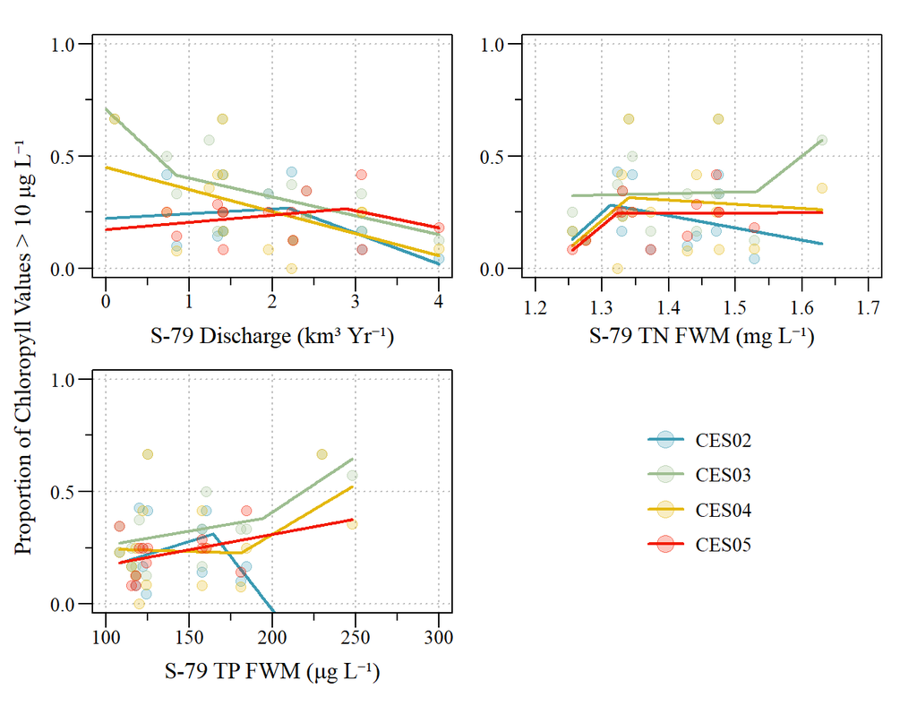

### Segmented Regression

| Variable | Estuary Site | Break-point | Break-point Standard Error | Model RSE | Model R² |
| --- | --- | --- | --- | --- | --- |
| S79 Discharge | CES02 | 2.19 | 0.96 | 0.13 | 0.27 |

### Next Steps

- Further statistical evaluation of segmented models

- Evaluate other factors in segmented regression approach.

- Evaluate tipping points at estuary sites versus a moving 30, 60, 90-day cumulative discharge and FWM at S-79.

- Evaluate tipping points for each site versus _in-situ_ parameters (i.e. color, TP, TP:TN, SRP:DIN, etc.)

Project analysis, information and presentation can be found at [https://github.com/SwampThingPaul/EstuaryTip](https://github.com/SwampThingPaul/EstuaryTip)